# Ebola Virus Disease

Mei Ying Tan

December 5, 2017

*Source file* ⇒ project.Rmd

## Overview, Symptoms & Preventions

The image below provides an overview of Ebola virus disease, symptoms, and some prevention steps recommended by the professionals.

[figure not shown]

## Read in .CSV dataset

```r
ebola <-
  read.csv("https://ds-ec2.scraperwiki.com/g7nnqgn/ckm9nsfssakeuor/cgi-bin/csv/ebola_data_db_format.csv")
```

I got the CSV dataset online so that it could be loaded into the Rstudio environment. Also, I had further renamed the dateset as ebola.

**Here is what the first 5 rows of my data table look like:**

```r
ebola %>%
  head(5)
```

```
##                                                             Indicator
## 1  Cumulative number of confirmed, probable and suspected Ebola cases
## 2                          Cumulative number of confirmed Ebola cases
## 3                           Cumulative number of probable Ebola cases
## 4                          Cumulative number of suspected Ebola cases
## 5 Cumulative number of confirmed, probable and suspected Ebola deaths
##   Country       Date value
## 1  Guinea 2015-03-10  3285
## 2  Guinea 2015-03-10  2871
## 3  Guinea 2015-03-10   392
## 4  Guinea 2015-03-10    22
## 5  Guinea 2015-03-10  2170
```

## Cumulative number of confirmed Ebola cases

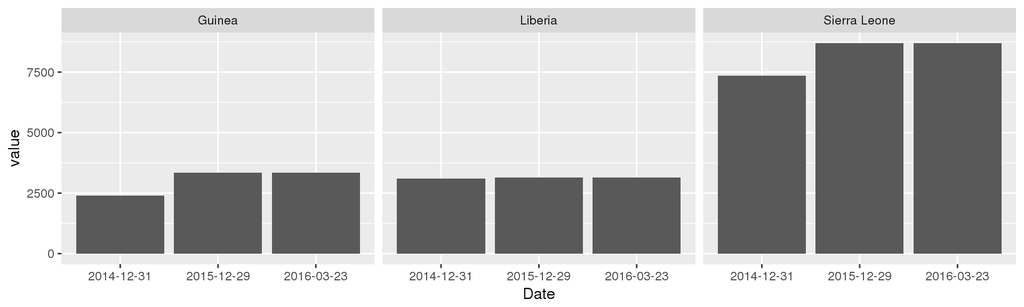

```r
ebola1 <-
  ebola %>%
  filter(Indicator == "Cumulative number of confirmed Ebola cases", value > 100, Date %in% c("2015-12-29", "2014-12-31", "2016-03-23"))

ebola1 %>%
  ggplot(aes(Date, value)) + geom_col()+ facet_wrap(~Country)
```

## Cumulative number of probable Ebola cases

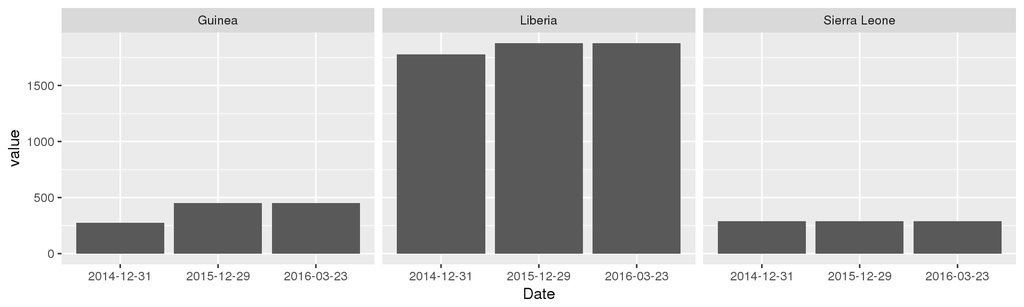

```r
ebola2 <-
  ebola %>%
  filter(Indicator == "Cumulative number of probable Ebola cases", value > 100, Date %in% c("2015-12-29", "2014-12-31", "2016-03-23"))

ebola2 %>%
  ggplot(aes(Date, value)) + geom_col()+ facet_wrap(~Country)
```

## Cumulative number of suspected Ebola cases

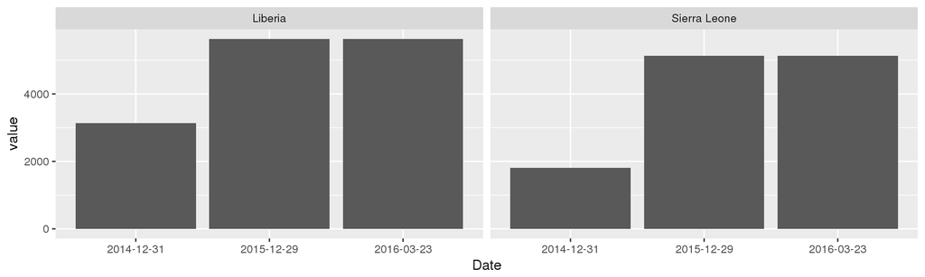

```r
ebola3 <-
  ebola %>%
  filter(Indicator == "Cumulative number of suspected Ebola cases", value > 100, Date %in% c("2015-12-29", "2014-12-31", "2016-03-23"))

ebola3 %>%
  ggplot(aes(Date, value)) + geom_col()+ facet_wrap(~Country)
```

## Cumulative number of confirmed, probable, and suspected Ebola cases

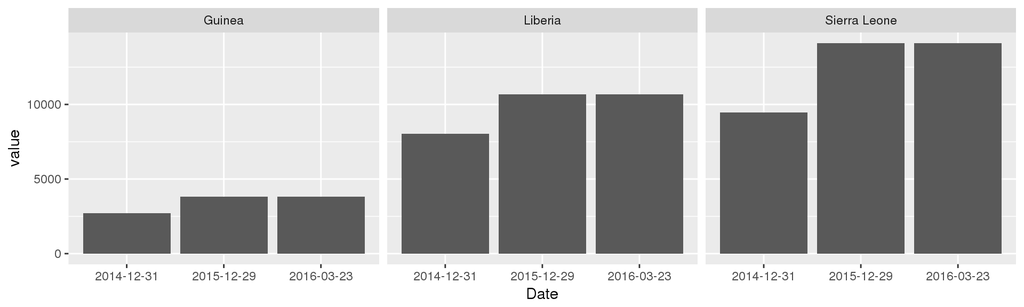

```r
ebola4 <-
  ebola %>%
  filter(Indicator == "Cumulative number of confirmed, probable and suspected Ebola cases", value > 100, Date %in% c("2015-12-29", "2014-12-31", "2016-03-23"))

ebola4 %>%
  ggplot(aes(Date, value)) + geom_col()+ facet_wrap(~Country)
```

Based on my research, the most recent Ebola outbreak was in West Africa, (first cases notified in 2014), it was the largest and most complex Ebola outbreak since the Ebola virus was first discovered in 1976. To support this statement, I have filtered out cases which its value is greater than 100 (indicating Ebola outbreak) occuring in years between 2014, 2015, and 2016. Furthermore, I have created a bar graph where the heights of the bars representing the values (total cumulative number of confirmed Ebola cases reported) in the data table. By observing the bar graph above, it was indeed that the three of the countries which located in the West Africa(Guinea, Liberia, and Sierra Leone) had the most serious Ebola outbreak from year 2014 to 2016. Moreover, Sierra Leone had the highest cumulative number of confirmed Ebola cases while Liberia had the highest cumulative number of probable Ebola cases. However, among the three countries, Sierra Leone experienced the largest Ebola outbreak since it had the highest cumulative number of confirmed, probable, and suspected Ebola cases.

## Read in .CSV dataset

```r
Gender <-
  read.csv("CASES.csv",header = TRUE, sep=",")
```

This dataset provides a useful information on the number of Ebola Virus Disease among Male and Female Persons in Guinea, Liberia, and Sierra Leone in 2014.

## Calculate the sum, mean, and median of affected male by Ebola virus

```r
EbolaMale <-
  Gender %>%
  filter(Gender == "M")%>%
  summarise(Count=sum(Total), Average = mean(Total), Median = median(Total))

kable(EbolaMale)
```

| Count | Average | Median |
| --- | --- | --- |
| 8333 | 2777.667 | 1911 |

I have filtered out cases where the variable Gender matches “M” for males and computed its sum, average, and median.

## Calculate the sum, mean, and median of affected female by Ebola virus

```r
EbolaFemale <-
  Gender %>%
  filter(Gender == "F")%>%
  summarise(Count=sum(Total), Average = mean(Total), Median = median(Total))

kable(EbolaFemale)
```

| Count | Average | Median |
| --- | --- | --- |
| 8703 | 2901 | 1838 |

I repeated the same procedure by filtering out the cases where the variable Gender matches “F” for females.

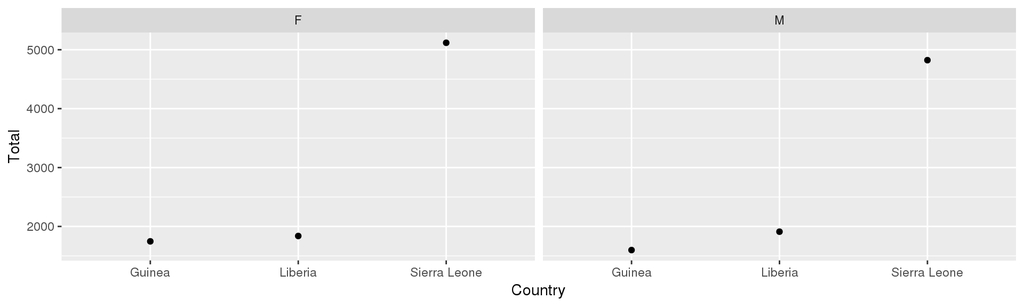

```r
Gender %>%
  ggplot(aes(x = Country, y = Total))+geom_point()+facet_wrap(~Gender)
```

Based on the results above, it shows that females tend to have a higher chance of getting affected by Ebola virus than males.

## Read in .CSV dataset

```r
Age <-
  read.csv("Age.csv",header = TRUE, sep=",") %>%
  rename(Age0to14 = X0.14, Age15to44 = X15.44, Age45andAbove = X45.)
```

This dataset shows the number of Ebola affected patients grouped by ages in Guinea, Liberia, and Sierra Leone in 2014. Also, I renamed the variables so that it makes more sense while reading the data table.

## Number of Ebola affected patients from age 0 to 14

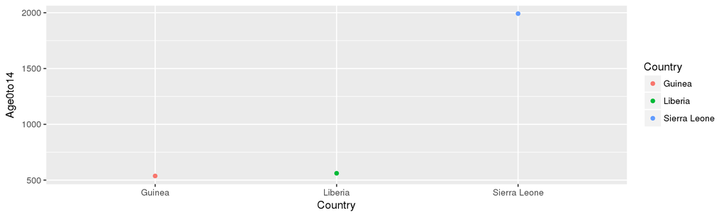

```r
Age%>%
  ggplot(aes(x = Country, y =Age0to14))+geom_point(aes(color = Country))
```

## Number of Ebola affected patients from age 15 to 44

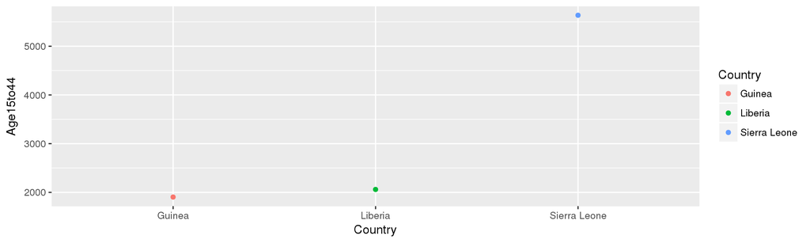

```r
Age %>%
  ggplot(aes(x = Country, y =Age15to44))+geom_point(aes(color = Country))
```

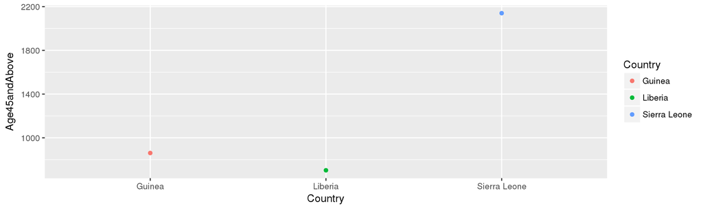

```r
Age %>%
  ggplot(aes(x = Country, y =Age45andAbove))+geom_point(aes(color = Country))
```

Based on the results above, it is found that patients from age 15 to 44 have a higher risk of getting affected by Ebola virus.